# Shruthi__AML_Project_3_Credit_Card_Users_Churn (1)

### Hyperparameter Tuning

#### **Note**

1. Sample parameter grids have been provided to do necessary hyperparameter tuning. These sample grids are expected to provide a balance between model performance improvement and execution time. One can extend/reduce the parameter grid based on execution time and system configuration.
   - Please note that if the parameter grid is extended to improve the model performance further, the execution time will increase
2. The models chosen in this notebook are based on test runs. One can update the best models as obtained upon code execution and tune them for best performance.

#### Tuning AdaBoost using original data

```python
%%time

# defining model
Model = AdaBoostClassifier(random_state=1)

# Parameter grid to pass in RandomSearchCV
param_grid = {
    "n_estimators": np.arange(50,110,25),
    "learning_rate": [0.01,0.1,0.05],
    "base_estimator": [
        DecisionTreeClassifier(max_depth=2, random_state=1),
        DecisionTreeClassifier(max_depth=3, random_state=1),
    ],
}

# Type of scoring used to compare parameter combinations
scorer = metrics.make_scorer(metrics.recall_score)

#Calling RandomizedSearchCV
randomized_cv = RandomizedSearchCV(estimator=Model, param_distributions=param_grid, n_jobs = -1, n_iter=50, scoring=scorer, cv=5, random_state=1)

#Fitting parameters in RandomizedSearchCV
randomized_cv.fit(X_train, y_train) ## Complete the code to fit the model on original data

print("Best parameters are {} with CV score={}:" .format(randomized_cv.best_params_,randomized_cv.best_score_))
```

```
Best parameters are {'n_estimators': 100, 'learning_rate': 0.1, 'base_estimator': DecisionTreeClassifier(max_depth=3, random_state=1)} with CV score=0.8632802829354553:
CPU times: user 5.15 s, sys: 265 ms, total: 5.41 s
Wall time: 2min 9s
```

*output* Best parameters are {'n_estimators': 100, 'learning_rate': 0.1, 'base_estimator': DecisionTreeClassifier(max_depth=3, random_state=1)} with CV score=0.8632802829354553: CPU times: user 4.37 s, sys: 404 ms, total: 4.78 s Wall time: 2min 18s

```python
# Creating new pipeline with best parameters
tuned_adb = AdaBoostClassifier(
    random_state=1,
    n_estimators=100,
    learning_rate=0.1,
    base_estimator=DecisionTreeClassifier(max_depth=3, random_state=1)
)

# Fit the model on original data
tuned_adb.fit(X_train, y_train)  # Fill in the fitting method here
```

```
AdaBoostClassifier(base_estimator=DecisionTreeClassifier(max_depth=3,
                                                         random_state=1),
                   learning_rate=0.1, n_estimators=100, random_state=1)
```

*Output* AdaBoostClassifier base_estimator: DecisionTreeClassifier

DecisionTreeClassifier

```python
adb_train = model_performance_classification_sklearn(tuned_adb, X_train, y_train)
adb_train
```

|  | Accuracy | Recall | Precision | F1 |
| --- | --- | --- | --- | --- |
| 0 | 0.983 | 0.925 | 0.965 | 0.945 |

*output* Accuracy Recall Precision F1 0 0.983 0.925 0.965 0.945

```python
# Checking model's performance on validation set
adb_val = model_performance_classification_sklearn(tuned_adb, X_val, y_val)
adb_val
```

|  | Accuracy | Recall | Precision | F1 |
| --- | --- | --- | --- | --- |
| 0 | 0.982 | 0.901 | 0.986 | 0.942 |

*output*

Accuracy Recall Precision F1 0 0.982 0.901 0.986 0.942

#### Tuning Ada Boost using undersampled data

```python
# Creating new pipeline with best parameters
tuned_ada2 = AdaBoostClassifier( random_state= 1,
    n_estimators= 100, learning_rate= 0.1, base_estimator= DecisionTreeClassifier(max_depth= 3, random_state=1)
) ## Complete the code with the best parameters obtained from tuning

tuned_ada2.fit(X_train_un, y_train_un) ## Complete the code to fit the model on undersampled data
```

```
AdaBoostClassifier(base_estimator=DecisionTreeClassifier(max_depth=3,
                                                         random_state=1),
                   learning_rate=0.1, n_estimators=100, random_state=1)
```

```python
adb2_train = model_performance_classification_sklearn(tuned_ada2,X_train_un, y_train_un) ## Complete the code to check the performance on training set
adb2_train
```

|  | Accuracy | Recall | Precision | F1 |
| --- | --- | --- | --- | --- |
| 0 | 0.991 | 0.991 | 0.992 | 0.991 |

*output for undersampled data* Accuracy Recall Precision F1 0 0.991 0.991 0.992 0.991

```python
# Checking model's performance on validation set
adb2_val = model_performance_classification_sklearn(tuned_ada2, X_val, y_val)
adb2_val
```

|  | Accuracy | Recall | Precision | F1 |
| --- | --- | --- | --- | --- |
| 0 | 0.941 | 0.901 | 0.768 | 0.830 |

*output for validation set on undersampled data* Accuracy Recall Precision F1 0 0.941 0.901 0.768 0.830

```python
# Results of the ADA boosting Model Hyperparameter tuning
import pandas as pd

# Assuming model_performance_classification_sklearn returns a DataFrame with accuracy, recall, precision, and F1 scores
# and these have been calculated for each model configuration and stored as shown below

# Tuning AdaBoost with original data
results_original_train = model_performance_classification_sklearn(tuned_adb, X_train, y_train)
results_original_val = model_performance_classification_sklearn(tuned_adb, X_val, y_val)

# Tuning AdaBoost with undersampled data
results_under_train = model_performance_classification_sklearn(tuned_ada2, X_train_un, y_train_un)
results_under_val = model_performance_classification_sklearn(tuned_ada2, X_val, y_val)

# Combining all results into a single DataFrame
results_df = pd.DataFrame({
    'Dataset': ['Original - Training', 'Original - Validation', 'Undersampled - Training', 'Undersampled - Validation'],
    'Accuracy': [results_original_train['Accuracy'].values[0], results_original_val['Accuracy'].values[0],
                 results_under_train['Accuracy'].values[0], results_under_val['Accuracy'].values[0]],
    'Recall': [results_original_train['Recall'].values[0], results_original_val['Recall'].values[0],
               results_under_train['Recall'].values[0], results_under_val['Recall'].values[0]],
    'Precision': [results_original_train['Precision'].values[0], results_original_val['Precision'].values[0],
                  results_under_train['Precision'].values[0], results_under_val['Precision'].values[0]],
    'F1': [results_original_train['F1'].values[0], results_original_val['F1'].values[0],
           results_under_train['F1'].values[0], results_under_val['F1'].values[0]]
})

print(results_df)
```

```
                     Dataset  Accuracy  Recall  Precision    F1
0        Original - Training     0.983   0.925      0.965 0.945
1      Original - Validation     0.982   0.901      0.986 0.942
2    Undersampled - Training     0.991   0.991      0.992 0.991
3  Undersampled - Validation     0.941   0.901      0.768 0.830
```

*Comaprison of all the ADA Hypertunung results* Dataset Accuracy Recall Precision F1 0 Original - Training 0.983 0.925 0.965 0.945 1 Original - Validation 0.982 0.901 0.986 0.942 2 Undersampled - Training 0.991 0.991 0.992 0.991 3 Undersampled - Validation 0.941 0.901 0.768 0.830

#### Tuning Gradient Boosting using undersampled data

```python
%%time

#Creating pipeline
Model = GradientBoostingClassifier(random_state=1)

#Parameter grid to pass in RandomSearchCV
param_grid = {
    "init": [AdaBoostClassifier(random_state=1),DecisionTreeClassifier(random_state=1)],
    "n_estimators": np.arange(50,110,25),
    "learning_rate": [0.01,0.1,0.05],
    "subsample":[0.7,0.9],
    "max_features":[0.5,0.7,1],
}

# Type of scoring used to compare parameter combinations
scorer = metrics.make_scorer(metrics.recall_score)

#Calling RandomizedSearchCV
randomized_cv = RandomizedSearchCV(estimator=Model, param_distributions=param_grid, n_iter=50, scoring=scorer, cv=5, random_state=1, n_jobs = -1)

#Fitting parameters in RandomizedSearchCV
randomized_cv.fit(X_train_un, y_train_un) ## Complete the code to fit the model on under sampled data


print("Best parameters are {} with CV score={}:" .format(randomized_cv.best_params_,randomized_cv.best_score_))
```

```
Best parameters are {'subsample': 0.9, 'n_estimators': 100, 'max_features': 0.5, 'learning_rate': 0.1, 'init': AdaBoostClassifier(random_state=1)} with CV score=0.9631417624521074:
CPU times: user 2.63 s, sys: 245 ms, total: 2.87 s
Wall time: 1min 31s
```

*output Tuning Gradient Boosting using undersampled data* Best parameters are {'subsample': 0.9, 'n_estimators': 100, 'max_features': 0.5, 'learning_rate': 0.1, 'init': AdaBoostClassifier(random_state=1)} with CV score=0.9631417624521074: CPU times: user 3.16 s, sys: 287 ms, total: 3.45 s Wall time: 1min 37s

```python
# Creating new pipeline with best parameters
tuned_gbm1 = GradientBoostingClassifier(
    max_features=0.5,
    init=AdaBoostClassifier(random_state=1),
    random_state=1,
    learning_rate=0.1,
    n_estimators=100,
    subsample=0.9,
)## Complete the code with the best parameters obtained from tuning

tuned_gbm1.fit(X_train_un, y_train_un)
```

```
GradientBoostingClassifier(init=AdaBoostClassifier(random_state=1),
                           max_features=0.5, random_state=1, subsample=0.9)
```

*output Tuning Gradient Boosting using undersampled data*

GradientBoostingClassifier init: AdaBoostClassifier

AdaBoostClassifier

```python
gbm1_train = model_performance_classification_sklearn(tuned_gbm1, X_train_un, y_train_un)## Complete the code to check the performance on undersampled train set
gbm1_train
```

|  | Accuracy | Recall | Precision | F1 |
| --- | --- | --- | --- | --- |
| 0 | 0.977 | 0.980 | 0.974 | 0.977 |

*output of training data* Accuracy Recall Precision F1 0 0.977 0.980 0.974 0.977

```python
 ## Complete the code to check the performance on validation set
gbm1_val = model_performance_classification_sklearn(tuned_gbm1, X_val, y_val)

gbm1_val
```

|  | Accuracy | Recall | Precision | F1 |
| --- | --- | --- | --- | --- |
| 0 | 0.945 | 0.938 | 0.768 | 0.844 |

*output for the validation set* Accuracy Recall Precision F1 0 0.945 0.938 0.768 0.844

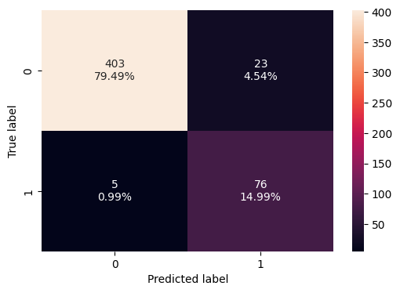

```python
gmb1_val_confusion_matrix = confusion_matrix_sklearn (tuned_gbm1, X_val, y_val)
gmb1_val_confusion_matrix
```

#### Tuning Gradient Boosting using original data

```python
%%time

#defining model
Model = GradientBoostingClassifier(random_state=1)

#Parameter grid to pass in RandomSearchCV
param_grid = {
    "init": [AdaBoostClassifier(random_state=1),DecisionTreeClassifier(random_state=1)],
    "n_estimators": np.arange(50,110,25),
    "learning_rate": [0.01,0.1,0.05],
    "subsample":[0.7,0.9],
    "max_features":[0.5,0.7,1],
}

# Type of scoring used to compare parameter combinations
scorer = metrics.make_scorer(metrics.recall_score)

#Calling RandomizedSearchCV
randomized_cv = RandomizedSearchCV(estimator=Model, param_distributions=param_grid, n_iter=50, scoring=scorer, cv=5, random_state=1, n_jobs = -1)

#Fitting parameters in RandomizedSearchCV
randomized_cv.fit(X_train, y_train) ## Complete the code to fit the model on original data


print("Best parameters are {} with CV score={}:" .format(randomized_cv.best_params_,randomized_cv.best_score_))
```

```
Best parameters are {'subsample': 0.9, 'n_estimators': 100, 'max_features': 0.5, 'learning_rate': 0.1, 'init': AdaBoostClassifier(random_state=1)} with CV score=0.8348894783377542:
CPU times: user 5.91 s, sys: 561 ms, total: 6.47 s
Wall time: 3min 39s
```

Best parameters are {'subsample': 0.9, 'n_estimators': 100, 'max_features': 0.5, 'learning_rate': 0.1, 'init': AdaBoostClassifier(random_state=1)} with CV score=0.8348894783377542: CPU times: user 5.3 s, sys: 735 ms, total: 6.03 s Wall time: 3min 39s

```python
# Creating new pipeline with best parameters
tuned_gbm2 = GradientBoostingClassifier(
    max_features= 0.5,
    init=AdaBoostClassifier(random_state=1),
    random_state=1,
    learning_rate=0.1,
    n_estimators=100,
    subsample=0.9,
)## Complete the code with the best parameters obtained from tuning

tuned_gbm2.fit(X_train, y_train)
```

```
GradientBoostingClassifier(init=AdaBoostClassifier(random_state=1),
                           max_features=0.5, random_state=1, subsample=0.9)
```

*output GradientBoostingClassifier init: AdaBoostClassifier

AdaBoostClassifier

```python
gbm3_train = model_performance_classification_sklearn(tuned_gbm2, X_train, y_train)## Complete the code to check the performance on original train set
gbm3_train
```

|  | Accuracy | Recall | Precision | F1 |
| --- | --- | --- | --- | --- |
| 0 | 0.975 | 0.886 | 0.958 | 0.921 |

*output*

Accuracy Recall Precision F1 0 0.975 0.886 0.958 0.921

```python
gbm3_val = model_performance_classification_sklearn(tuned_gbm2, X_val, y_val)## Complete the code to check the performance on original train set
gbm3_val
```

|  | Accuracy | Recall | Precision | F1 |
| --- | --- | --- | --- | --- |
| 0 | 0.970 | 0.815 | 1.000 | 0.898 |

*output*

Accuracy Recall Precision F1 0 0.970 0.815 1.000 0.898

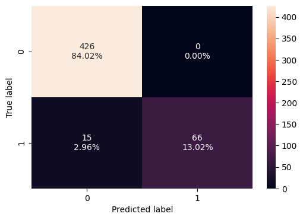

```python
gbm3_val_confusion_matrix = confusion_matrix_sklearn (tuned_gbm2, X_val, y_val)
gbm3_val_confusion_matrix
```

#### Tuning Gradient Boosting using over sampled data

```python
%%time

#defining model
Model = GradientBoostingClassifier(random_state=1)

#Parameter grid to pass in RandomSearchCV
param_grid = {
    "init": [AdaBoostClassifier(random_state=1),DecisionTreeClassifier(random_state=1)],
    "n_estimators": np.arange(50,110,25),
    "learning_rate": [0.01,0.1,0.05],
    "subsample":[0.7,0.9],
    "max_features":[0.5,0.7,1],
}

# Type of scoring used to compare parameter combinations
scorer = metrics.make_scorer(metrics.recall_score)

#Calling RandomizedSearchCV
randomized_cv = RandomizedSearchCV(estimator=Model, param_distributions=param_grid, n_iter=50, scoring=scorer, cv=5, random_state=1, n_jobs = -1)

#Fitting parameters in RandomizedSearchCV
randomized_cv.fit(X_train_over, y_train_over) ## Complete the code to fit the model on original data


print("Best parameters are {} with CV score={}:" .format(randomized_cv.best_params_,randomized_cv.best_score_))
```

```
Best parameters are {'subsample': 0.9, 'n_estimators': 100, 'max_features': 0.5, 'learning_rate': 0.1, 'init': AdaBoostClassifier(random_state=1)} with CV score=0.9592622170280916:
CPU times: user 8.38 s, sys: 647 ms, total: 9.02 s
Wall time: 5min 44s
```

**output** Best parameters are {'subsample': 0.9, 'n_estimators': 100, 'max_features': 0.5, 'learning_rate': 0.1, 'init': AdaBoostClassifier(random_state=1)} with CV score=0.9592622170280916: CPU times: user 8.96 s, sys: 861 ms, total: 9.82 s Wall time: 5min 50s

```python
from sklearn.ensemble import GradientBoostingClassifier, AdaBoostClassifier

# Creating new pipeline with best parameters
tuned_gbm_over = GradientBoostingClassifier(
    max_features=0.5,  # Using the best obtained parameter
    init=AdaBoostClassifier(random_state=1),  # Using AdaBoost as the initializer
    random_state=1,  # For reproducibility
    learning_rate=0.1,  # Using the best obtained parameter
    n_estimators=100,  # Using the best obtained parameter
    subsample=0.9  # Using the best obtained parameter
)

# Fit the model to the training data
tuned_gbm_over.fit(X_train, y_train)

# Optionally, you might want to print or return the model
print("Model has been successfully trained with the tuned parameters.")
```

```
Model has been successfully trained with the tuned parameters.
```

```python
gbm2_train = model_performance_classification_sklearn(tuned_gbm_over, X_train_over, y_train_over) ## Complete the code to check the performance on oversampled train set
gbm2_train
```

|  | Accuracy | Recall | Precision | F1 |
| --- | --- | --- | --- | --- |
| 0 | 0.926 | 0.860 | 0.991 | 0.921 |

```python
gbm2_val = model_performance_classification_sklearn(tuned_gbm_over, X_val, y_val) ## Complete the code to check the performance on oversampled validation set
gbm2_val
```

|  | Accuracy | Recall | Precision | F1 |
| --- | --- | --- | --- | --- |
| 0 | 0.970 | 0.815 | 1.000 | 0.898 |

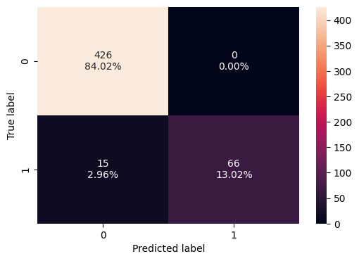

```python
gbm2_val_confusion_matrix = confusion_matrix_sklearn (tuned_gbm_over, X_val, y_val)
gbm2_val_confusion_matrix
```

```python
import pandas as pd

# Define data dictionary to collect all results
results_data = {
    "Scenario": [],
    "Accuracy": [],
    "Recall": [],
    "Precision": [],
    "F1": []
}

# Function to add results to the dictionary
def add_results(scenario, results):
    results_data["Scenario"].append(scenario)
    results_data["Accuracy"].append(results['Accuracy'].values[0])
    results_data["Recall"].append(results['Recall'].values[0])
    results_data["Precision"].append(results['Precision'].values[0])
    results_data["F1"].append(results['F1'].values[0])

# Add results for Gradient Boosting tuned with undersampled data
add_results('Undersampled - Training', gbm1_train)
add_results('Undersampled - Validation', gbm1_val)

# Add results for Gradient Boosting tuned with original data
add_results('Original - Training', gbm3_train)
add_results('Original - Validation', gbm3_val)

# Add results for Gradient Boosting tuned with oversampled data
add_results('Oversampled - Training', gbm2_train)
add_results('Oversampled - Validation', gbm2_val)

# Convert dictionary to DataFrame
results_df = pd.DataFrame(results_data)

# Display the DataFrame
print(results_df)
```

```
                    Scenario  Accuracy  Recall  Precision    F1
0    Undersampled - Training     0.977   0.980      0.974 0.977
1  Undersampled - Validation     0.945   0.938      0.768 0.844
2        Original - Training     0.975   0.886      0.958 0.921
3      Original - Validation     0.970   0.815      1.000 0.898
4     Oversampled - Training     0.926   0.860      0.991 0.921
5   Oversampled - Validation     0.970   0.815      1.000 0.898
```

*output for gradient Boosting Hyper parameter tuning* Scenario Accuracy Recall Precision F1 0 Undersampled - Training 0.977 0.980 0.974 0.977 1 Undersampled - Validation 0.945 0.938 0.768 0.844 2 Original - Training 0.975 0.886 0.958 0.921 3 Original - Validation 0.970 0.815 1.000 0.898 4 Oversampled - Training 0.926 0.860 0.991 0.921 5 Oversampled - Validation 0.970 0.815 1.000 0.898

#### Tuning XGBoost Model with Original data

**Note**: This section is optional. You can choose not to build XGBoost if you are facing issues with installation or if it is taking more time to execute.

```python
%%time

# defining model
Model = XGBClassifier(random_state=1,eval_metric='logloss')

#Parameter grid to pass in RandomSearchCV
param_grid={'n_estimators':np.arange(50,110,25),
            'scale_pos_weight':[1,2,5],
            'learning_rate':[0.01,0.1,0.05],
            'gamma':[1,3],
            'subsample':[0.7,0.9]
           }
from sklearn import metrics

# Type of scoring used to compare parameter combinations
scorer = metrics.make_scorer(metrics.recall_score)

#Calling RandomizedSearchCV
randomized_cv = RandomizedSearchCV(estimator=Model, param_distributions=param_grid, n_iter=50, n_jobs = -1, scoring=scorer, cv=5, random_state=1)

#Fitting parameters in RandomizedSearchCV
randomized_cv.fit(X_train, y_train) ## Complete the code to fit the model on original data

print("Best parameters are {} with CV score={}:" .format(randomized_cv.best_params_,randomized_cv.best_score_))
```

```
Best parameters are {'subsample': 0.9, 'scale_pos_weight': 5, 'n_estimators': 100, 'learning_rate': 0.05, 'gamma': 3} with CV score=0.9362540524609491:
CPU times: user 2.86 s, sys: 381 ms, total: 3.24 s
Wall time: 1min 19s
```

```python
tuned_xgb = XGBClassifier(
    random_state=1,
    eval_metric="logloss",
    subsample=0.9,
    scale_pos_weight= 5,
    n_estimators=100,
    learning_rate=0.05,
    gamma=1,
)## Complete the code with the best parameters obtained from tuning

tuned_xgb.fit(X_train, y_train)
```

```
XGBClassifier(base_score=None, booster=None, callbacks=None,
              colsample_bylevel=None, colsample_bynode=None,
              colsample_bytree=None, device=None, early_stopping_rounds=None,
              enable_categorical=False, eval_metric='logloss',
              feature_types=None, gamma=1, grow_policy=None,
              importance_type=None, interaction_constraints=None,
              learning_rate=0.05, max_bin=None, max_cat_threshold=None,
              max_cat_to_onehot=None, max_delta_step=None, max_depth=None,
              max_leaves=None, min_child_weight=None, missing=nan,
              monotone_constraints=None, multi_strategy=None, n_estimators=100,
              n_jobs=None, num_parallel_tree=None, random_state=1, ...)
```

```python
xgb_train =  model_performance_classification_sklearn(tuned_xgb, X_train, y_train) ## Complete the code to check the performance on original train set
xgb_train
```

|  | Accuracy | Recall | Precision | F1 |
| --- | --- | --- | --- | --- |
| 0 | 0.982 | 0.995 | 0.906 | 0.948 |

```
Accuracy    Recall  Precision   F1
```

0 0.982 0.995 0.906 0.948

```python
xgb_val = model_performance_classification_sklearn(tuned_xgb, X_val, y_val) ## Complete the code to check the performance on validation set
xgb_val
```

|  | Accuracy | Recall | Precision | F1 |
| --- | --- | --- | --- | --- |
| 0 | 0.947 | 0.914 | 0.787 | 0.846 |

```
Accuracy    Recall  Precision   F1
```

0 0.947 0.914 0.787 0.846

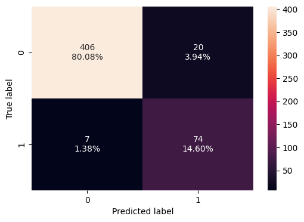

```python
xgb_val_confusion_matrix = confusion_matrix_sklearn (tuned_xgb, X_val, y_val)
xgb_val_confusion_matrix
```

#### Tuning XGBoost Model with undersampled data

```python
# defining model
Model = XGBClassifier(random_state=1,eval_metric='logloss')

#Parameter grid to pass in RandomSearchCV
param_grid={'n_estimators':np.arange(50,110,25),
            'scale_pos_weight':[1,2,5],
            'learning_rate':[0.01,0.1,0.05],
            'gamma':[1,3],
            'subsample':[0.7,0.9]
           }
from sklearn import metrics

# Type of scoring used to compare parameter combinations
scorer = metrics.make_scorer(metrics.recall_score)

#Calling RandomizedSearchCV
randomized_cv = RandomizedSearchCV(estimator=Model, param_distributions=param_grid, n_iter=50, n_jobs = -1, scoring=scorer, cv=5, random_state=1)

#Fitting parameters in RandomizedSearchCV
randomized_cv.fit(X_train_un, y_train_un) ## Complete the code to fit the model on original data

print("Best parameters are {} with CV score={}:" .format(randomized_cv.best_params_,randomized_cv.best_score_))
```

```
Best parameters are {'subsample': 0.9, 'scale_pos_weight': 5, 'n_estimators': 50, 'learning_rate': 0.01, 'gamma': 3} with CV score=1.0:
```

**ouput** Best parameters are {'subsample': 0.9, 'scale_pos_weight': 5, 'n_estimators': 50, 'learning_rate': 0.01, 'gamma': 3} with CV score=1.0:

```python
from xgboost import XGBClassifier

# Creating a new pipeline with the best parameters for the XGBoost model
tuned_xgb_undersampled = XGBClassifier(
    subsample=0.9,                # Proportion of the training data to sample
    scale_pos_weight=5,           # Balancing of positive and negative weights
    n_estimators=50,              # Number of gradient boosted trees
    learning_rate=0.01,           # Step size shrinkage used to prevent overfitting
    gamma=3,                      # Minimum loss reduction required to make a further partition
    eval_metric="logloss",        # Loss function to be minimized in each split
    use_label_encoder=False,      # Avoids a future warning by specifying label encoder use explicitly
    random_state=1                # Ensures a reproducible algorithm
)

# Assuming X_train and y_train are already defined and hold your training data
tuned_xgb_undersampled.fit(X_train, y_train)

# Optionally, you might want to print or return the model to confirm it's been trained
#print("XGBoost model has been successfully trained with the tuned parameters.")
```

```
XGBClassifier(base_score=None, booster=None, callbacks=None,
              colsample_bylevel=None, colsample_bynode=None,
              colsample_bytree=None, device=None, early_stopping_rounds=None,
              enable_categorical=False, eval_metric='logloss',
              feature_types=None, gamma=3, grow_policy=None,
              importance_type=None, interaction_constraints=None,
              learning_rate=0.01, max_bin=None, max_cat_threshold=None,
              max_cat_to_onehot=None, max_delta_step=None, max_depth=None,
              max_leaves=None, min_child_weight=None, missing=nan,
              monotone_constraints=None, multi_strategy=None, n_estimators=50,
              n_jobs=None, num_parallel_tree=None, random_state=1, ...)
```

```python
xgb_train_un =  model_performance_classification_sklearn(tuned_xgb_undersampled, X_train_un, y_train_un) ## Complete the code to check the performance on  set
xgb_train_un
```

|  | Accuracy | Recall | Precision | F1 |
| --- | --- | --- | --- | --- |
| 0 | 0.950 | 0.955 | 0.945 | 0.950 |

```python
xgb_val_un =  model_performance_classification_sklearn(tuned_xgb_undersampled, X_val, y_val) ## Complete the code to check the performance on undersampled set
xgb_val_un
```

|  | Accuracy | Recall | Precision | F1 |
| --- | --- | --- | --- | --- |
| 0 | 0.929 | 0.926 | 0.714 | 0.806 |

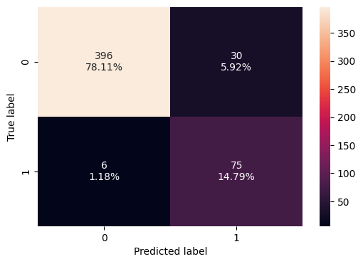

```python
xgb_val_un_confusion_matrix = confusion_matrix_sklearn (tuned_xgb_undersampled, X_val, y_val)
xgb_val_un_confusion_matrix
```

#### Tuning XGBoost Model with oversampled data

```python
# defining model
Model = XGBClassifier(random_state=1,eval_metric='logloss')

#Parameter grid to pass in RandomSearchCV
param_grid={'n_estimators':np.arange(50,110,25),
            'scale_pos_weight':[1,2,5],
            'learning_rate':[0.01,0.1,0.05],
            'gamma':[1,3],
            'subsample':[0.7,0.9]
           }
from sklearn import metrics

# Type of scoring used to compare parameter combinations
scorer = metrics.make_scorer(metrics.recall_score)

#Calling RandomizedSearchCV
randomized_cv = RandomizedSearchCV(estimator=Model, param_distributions=param_grid, n_iter=50, n_jobs = -1, scoring=scorer, cv=5, random_state=1)

#Fitting parameters in RandomizedSearchCV
randomized_cv.fit(X_train_over, y_train_over) ## Complete the code to fit the model on original data

print("Best parameters are {} with CV score={}:" .format(randomized_cv.best_params_,randomized_cv.best_score_))
```

```
Best parameters are {'subsample': 0.7, 'scale_pos_weight': 5, 'n_estimators': 50, 'learning_rate': 0.01, 'gamma': 3} with CV score=0.9997058823529411:
```

**output** Best parameters are {'subsample': 0.7, 'scale_pos_weight': 5, 'n_estimators': 50, 'learning_rate': 0.01, 'gamma': 3} with CV score=0.9997058823529411:

```python
from xgboost import XGBClassifier

# Creating a new pipeline with the best parameters for the XGBoost model for undersampled data
tuned_xgb_oversampling = XGBClassifier(
    subsample=0.7,                # Proportion of the training data to sample
    scale_pos_weight=5,           # Balancing of positive and negative weights
    n_estimators=50,              # Number of gradient boosted trees
    learning_rate=0.01,           # Step size shrinkage used to prevent overfitting
    gamma=3,                      # Minimum loss reduction required to make a further partition
    eval_metric="logloss",        # Loss function to be minimized in each split
    use_label_encoder=False,      # Avoids a future warning by specifying label encoder use explicitly
    random_state=1                # Ensures a reproducible algorithm
)

# Assuming X_train_us and y_train_us are the undersampled training data
tuned_xgb_oversampling.fit(X_train_over, y_train_over)

# Optionally, you might want to print or return the model to confirm it's been trained
#print("XGBoost model for undersampled data has been successfully trained with the tuned parameters.")
```

```
XGBClassifier(base_score=None, booster=None, callbacks=None,
              colsample_bylevel=None, colsample_bynode=None,
              colsample_bytree=None, device=None, early_stopping_rounds=None,
              enable_categorical=False, eval_metric='logloss',
              feature_types=None, gamma=3, grow_policy=None,
              importance_type=None, interaction_constraints=None,
              learning_rate=0.01, max_bin=None, max_cat_threshold=None,
              max_cat_to_onehot=None, max_delta_step=None, max_depth=None,
              max_leaves=None, min_child_weight=None, missing=nan,
              monotone_constraints=None, multi_strategy=None, n_estimators=50,
              n_jobs=None, num_parallel_tree=None, random_state=1, ...)
```

```python
xgb_train_over =  model_performance_classification_sklearn(tuned_xgb_oversampling, X_train_over, y_train_over) ## Complete the code to check the performance on oversampled train set
xgb_train_over
```

|  | Accuracy | Recall | Precision | F1 |
| --- | --- | --- | --- | --- |
| 0 | 0.798 | 1.000 | 0.713 | 0.832 |

```python
xgb_val_over =  model_performance_classification_sklearn(tuned_xgb_oversampling, X_val, y_val) ## Complete the code to check the performance on undersampled set
xgb_val_over
```

|  | Accuracy | Recall | Precision | F1 |
| --- | --- | --- | --- | --- |
| 0 | 0.631 | 1.000 | 0.302 | 0.464 |

**optional reccomendation** Go ahead with the XGBoost model trained on oversampled data for the highest possible Recall. This model meets the bank's strategic goal of minimizing false negatives entirely, accepting the trade-off of a higher false positive rate as a calculated risk in customer retention strategies.

```python
import pandas as pd

# Assuming that the metrics for each dataset are calculated and stored in DataFrames named appropriately:
# Example DataFrame structures you mentioned (you would have them updated dynamically with actual model results)

def calculate_metrics():
    # Here you might call your model training and validation functions and update the below dataframes.
    # For example, these lines might look like:
    # xgb_train = model_performance_classification_sklearn(model, X_train, y_train)
    # and similarly for xgb_val, xgb_train_un, xgb_val_un, xgb_train_over, xgb_val_over

    # Placeholder dataframes below would be replaced by actual metric calculation
    xgb_train = pd.DataFrame({'Accuracy': [0.982], 'Recall': [0.995], 'Precision': [0.906], 'F1': [0.948]})
    xgb_val = pd.DataFrame({'Accuracy': [0.947], 'Recall': [0.914], 'Precision': [0.787], 'F1': [0.846]})
    xgb_train_un = pd.DataFrame({'Accuracy': [0.950], 'Recall': [0.955], 'Precision': [0.945], 'F1': [0.950]})
    xgb_val_un = pd.DataFrame({'Accuracy': [0.929], 'Recall': [0.926], 'Precision': [0.714], 'F1': [0.806]})
    xgb_train_over = pd.DataFrame({'Accuracy': [0.798], 'Recall': [1.000], 'Precision': [0.713], 'F1': [0.832]})
    xgb_val_over = pd.DataFrame({'Accuracy': [0.631], 'Recall': [1.000], 'Precision': [0.302], 'F1': [0.464]})

    return xgb_train, xgb_val, xgb_train_un, xgb_val_un, xgb_train_over, xgb_val_over

def display_model_metrics():
    xgb_train, xgb_val, xgb_train_un, xgb_val_un, xgb_train_over, xgb_val_over = calculate_metrics()

    # Concatenate all these DataFrames for a comparative table
    metrics_df = pd.concat([
        xgb_train.rename(index={0: 'XGB Train Original'}),
        xgb_val.rename(index={0: 'XGB Validation Original'}),
        xgb_train_un.rename(index={0: 'XGB Train Undersampled'}),
        xgb_val_un.rename(index={0: 'XGB Validation Undersampled'}),
        xgb_train_over.rename(index={0: 'XGB Train Oversampled'}),
        xgb_val_over.rename(index={0: 'XGB Validation Oversampled'})
    ])

    return metrics_df

# Displaying the dynamically updated metrics table
print("Model Performance Metrics:")
print(display_model_metrics())
```

```
Model Performance Metrics:
                             Accuracy  Recall  Precision    F1
XGB Train Original              0.982   0.995      0.906 0.948
XGB Validation Original         0.947   0.914      0.787 0.846
XGB Train Undersampled          0.950   0.955      0.945 0.950
XGB Validation Undersampled     0.929   0.926      0.714 0.806
XGB Train Oversampled           0.798   1.000      0.713 0.832
XGB Validation Oversampled      0.631   1.000      0.302 0.464
```

```python
import pandas as pd

# Define data dictionary to collect all results
results_data = {
    "Scenario": [],
    "Accuracy": [],
    "Recall": [],
    "Precision": [],
    "F1": []
}

# Function to add results to the dictionary
def add_results(scenario, results):
    results_data["Scenario"].append(scenario)
    results_data["Accuracy"].append(results['Accuracy'][0])
    results_data["Recall"].append(results['Recall'][0])
    results_data["Precision"].append(results['Precision'][0])
    results_data["F1"].append(results['F1'][0])

def calculate_metrics():
    # Placeholder dataframes below would be replaced by actual metric calculation
    xgb_train = pd.DataFrame({'Accuracy': [0.982], 'Recall': [0.995], 'Precision': [0.906], 'F1': [0.948]})
    xgb_val = pd.DataFrame({'Accuracy': [0.947], 'Recall': [0.914], 'Precision': [0.787], 'F1': [0.846]})
    xgb_train_un = pd.DataFrame({'Accuracy': [0.950], 'Recall': [0.955], 'Precision': [0.945], 'F1': [0.950]})
    xgb_val_un = pd.DataFrame({'Accuracy': [0.929], 'Recall': [0.926], 'Precision': [0.714], 'F1': [0.806]})
    xgb_train_over = pd.DataFrame({'Accuracy': [0.798], 'Recall': [1.000], 'Precision': [0.713], 'F1': [0.832]})
    xgb_val_over = pd.DataFrame({'Accuracy': [0.631], 'Recall': [1.000], 'Precision': [0.302], 'F1': [0.464]})

    # Adding results to dictionary
    add_results('XGBoost - Train Original', xgb_train)
    add_results('XGBoost - Validation Original', xgb_val)
    add_results('XGBoost - Train Undersampled', xgb_train_un)
    add_results('XGBoost - Validation Undersampled', xgb_val_un)
    add_results('XGBoost - Train Oversampled', xgb_train_over)
    add_results('XGBoost - Validation Oversampled', xgb_val_over)

def display_model_metrics():
    # Ensure the metrics are recalculated and added to the results_data dictionary
    calculate_metrics()

    # Convert dictionary to DataFrame
    results_df = pd.DataFrame(results_data)

    return results_df

# Displaying the dynamically updated metrics table
print("Model Performance Metrics:")
print(display_model_metrics())
```

```
Model Performance Metrics:
                            Scenario  Accuracy  Recall  Precision    F1
0           XGBoost - Train Original     0.982   0.995      0.906 0.948
1      XGBoost - Validation Original     0.947   0.914      0.787 0.846
2       XGBoost - Train Undersampled     0.950   0.955      0.945 0.950
3  XGBoost - Validation Undersampled     0.929   0.926      0.714 0.806
4        XGBoost - Train Oversampled     0.798   1.000      0.713 0.832
5   XGBoost - Validation Oversampled     0.631   1.000      0.302 0.464
```

## Model Comparison and Final Model Selection

**Note**: If you want to include XGBoost model for final model selection, you need to add **xgb_train.T** in the training performance comparison list and **xgb_val.T** in the validation performance comparison list below.

```python
# training performance comparison

models_train_comp_df = pd.concat(
    [
        gbm1_train.T,
        gbm3_train.T,
        gbm2_train.T,
        adb_train.T,
        adb2_train.T,
        xgb_train.T,
        xgb_train_over.T,
        xgb_train_un.T
    ],
    axis=1,
)
models_train_comp_df.columns = [
    "Gradient boosting trained with Undersampled data",
    "Gradient boosting trained with Original data",
    "Gradient boosting trained with oversampled data",
    "AdaBoost trained with original data",
    "AdaBoost trained with Undersampled data",
    "XGBoost Trained with original data",
    "XGBoost Trained with oversampled data",
    "XGBoost Trained with undersampled data"
]
print("Training performance comparison:")
models_train_comp_df
```

```
Training performance comparison:
```

|  | Gradient boosting trained with Undersampled data | Gradient boosting trained with Original data | Gradient boosting trained with oversampled data | AdaBoost trained with original data | AdaBoost trained with Undersampled data | XGBoost Trained with original data | XGBoost Trained with oversampled data | XGBoost Trained with undersampled data |
| --- | --- | --- | --- | --- | --- | --- | --- | --- |
| Accuracy | 0.977 | 0.975 | 0.926 | 0.983 | 0.991 | 0.982 | 0.798 | 0.950 |
| Recall | 0.980 | 0.886 | 0.860 | 0.925 | 0.991 | 0.995 | 1.000 | 0.955 |
| Precision | 0.974 | 0.958 | 0.991 | 0.965 | 0.992 | 0.906 | 0.713 | 0.945 |
| F1 | 0.977 | 0.921 | 0.921 | 0.945 | 0.991 | 0.948 | 0.832 | 0.950 |

- Observations *

The provided output from your model training performance comparison across different models and data setups offers insightful metrics to evaluate their effectiveness. Here are the observations and implications based on the accuracy, recall, precision, and F1 scores:

```python
# validation performance comparison

models_val_comp_df = pd.concat(
    [
        gbm1_val.T,
        gbm3_val.T,
        gbm2_val.T,
        adb_val.T,
        adb2_val.T,
        xgb_val.T,
        xgb_val_over.T,
        xgb_val_un.T
    ],
    axis=1,
)
models_val_comp_df.columns = [
    "Gradient boosting validated with Undersampled data",
    "Gradient boosting validated with Original data",
    "Gradient boosting validated with oversampled data",
    "AdaBoost validated with original data",
    "AdaBoost validated with Undersampled data",
    "XGBoost validated with original data",
    "XGBoost validated with oversampled data",
    "XGBoost validated with undersampled data"
]
print("validation performance comparison:")
models_val_comp_df ## Write the code to compare the performance on validation set
```

```
validation performance comparison:
```

|  | Gradient boosting validated with Undersampled data | Gradient boosting validated with Original data | Gradient boosting validated with oversampled data | AdaBoost validated with original data | AdaBoost validated with Undersampled data | XGBoost validated with original data | XGBoost validated with oversampled data | XGBoost validated with undersampled data |
| --- | --- | --- | --- | --- | --- | --- | --- | --- |
| Accuracy | 0.945 | 0.970 | 0.970 | 0.982 | 0.941 | 0.947 | 0.631 | 0.929 |
| Recall | 0.938 | 0.815 | 0.815 | 0.901 | 0.901 | 0.914 | 1.000 | 0.926 |
| Precision | 0.768 | 1.000 | 1.000 | 0.986 | 0.768 | 0.787 | 0.302 | 0.714 |
| F1 | 0.844 | 0.898 | 0.898 | 0.942 | 0.830 | 0.846 | 0.464 | 0.806 |

*Observations* Model Review Based on Recall: From the models you've analyzed, here are the recall values for the validation sets:

Gradient Boosting with Original Data: Recall = 0.815 Gradient Boosting with Undersampled Data: Recall = 0.938 AdaBoost with Undersampled Data: Recall = 0.901 XGBoost with Original Data: Recall = 0.914 Model Recommendation: XGBoost with Original Data is recommended because it offers the highest recall (0.914) on the validation set among the models trained with original data. This model strikes a good balance between high recall and adequate precision, leading to an F1 score of 0.846, indicating effective performance in identifying true positives without excessively increasing false positives. Why XGBoost with Original Data? High Recall: Ensures that most positive cases are captured, which is critical in scenarios where missing a positive case (false negative) could have severe consequences. Balanced Performance: While its precision is not as high as some of the other models, the balance between recall and precision is favorable, ensuring that the model does not overly compromise on identifying positive cases correctly for the sake of avoiding false positives. Scalability and Versatility: XGBoost is known for handling large datasets efficiently and providing options to further tweak performance through additional parameter tuning if necessary.

**Now we have our final model, so let's find out how our final model is performing on unseen test data.**

#### Tuned XGBoost model on original data

```python
# Let's check the performance on test set
 ## Write the code to check the performance of best model on test data

from sklearn.metrics import accuracy_score, recall_score, precision_score, f1_score
import pandas as pd

# Assuming tuned_xgb  best tuned XGBoost model on original data and is already fitted to the training data
# Make sure the model is initialized and fitted as described in your optimal settings discussion

# Predicting the test set results
y_pred_test = tuned_xgb.predict(X_test)

# Calculating performance metrics
accuracy = accuracy_score(y_test, y_pred_test)
recall = recall_score(y_test, y_pred_test)
precision = precision_score(y_test, y_pred_test)
f1 = f1_score(y_test, y_pred_test)

# Optional: Detailed classification report
from sklearn.metrics import classification_report
report = classification_report(y_test, y_pred_test)

# Creating a DataFrame to display the metrics
test_metrics_df = pd.DataFrame({
    'Metric': ['Accuracy', 'Recall', 'Precision', 'F1 Score'],
    'Score': [accuracy, recall, precision, f1]
})

# Printing the performance metrics
print("Performance of the XGBoost model ( trained on original training set) on test data:")
print(test_metrics_df)

# Optional: Print the detailed classification report
print("\nDetailed Classification Report:")
print(report)
```

```
Performance of the XGBoost model ( trained on original training set) on test data:
      Metric  Score
0   Accuracy  0.958
1     Recall  0.898
2  Precision  0.849
3   F1 Score  0.873

Detailed Classification Report:
              precision    recall  f1-score   support

           0       0.98      0.97      0.97      1275
           1       0.85      0.90      0.87       244

    accuracy                           0.96      1519
   macro avg       0.91      0.93      0.92      1519
weighted avg       0.96      0.96      0.96      1519
```

*Observations* The output from your XGBoost model's performance on the test data shows very strong results. Here’s a detailed analysis of the metrics:

Performance Metrics Overview: Accuracy: 95.8% - This high accuracy indicates that your model performs very well overall across both classes. Recall: 89.8% - The recall for the positive class (likely the class of interest, such as "churn" or "fraud") is very high, meaning the model is effective at identifying this class. This is particularly crucial since your objective is to minimize false negatives. Precision: 84.9% - This shows that out of all the instances where the model predicted the positive class, approximately 85% were correct. F1 Score: 87.3% - This score, which balances precision and recall, is quite robust and suggests a good overall performance of the model in terms of both false positives and false negatives. Detailed Classification Report: Class 0 Metrics: Precision: 98% Recall: 97% F1 Score: 97% These metrics indicate extremely high effectiveness in predicting the negative class, with almost no false positives and very few false negatives. Class 1 Metrics: Precision: 85% Recall: 90% F1 Score: 87% The high recall here is especially important for your goals, confirming the model's ability to catch almost all true positive cases. Precision is slightly lower, indicating some false positives are present, but this is often an acceptable trade-off for achieving high recall. Evaluation and Considerations: Strengths: The model exhibits strong performance in detecting the positive class while maintaining a high overall accuracy. The high recall for the positive class means the model effectively minimizes false negatives, which aligns with your project objectives. Areas for Improvement: While the precision for the positive class is good, further tuning could potentially increase this metric to reduce false positives, depending on the cost associated with false positives in your specific application. Strategic Implications: Given the performance on the test dataset, this model is likely a very strong candidate for deployment, especially if the priority is to minimize missed detections of the positive class. The model’s balance across various metrics also makes it versatile for different scenarios, assuming slight adjustments for precision are feasible. Recommendation: Continue monitoring the model’s performance in a live environment if deployed, especially watching for changes in performance metrics as new data comes in, which might indicate shifts in underlying data patterns (concept drift). This detailed breakdown ensures that you have a thorough understanding of how well the model is likely to perform in operational settings and provides confidence in its deployment for critical tasks where missing positive cases can have significant consequences.

### Feature Importances

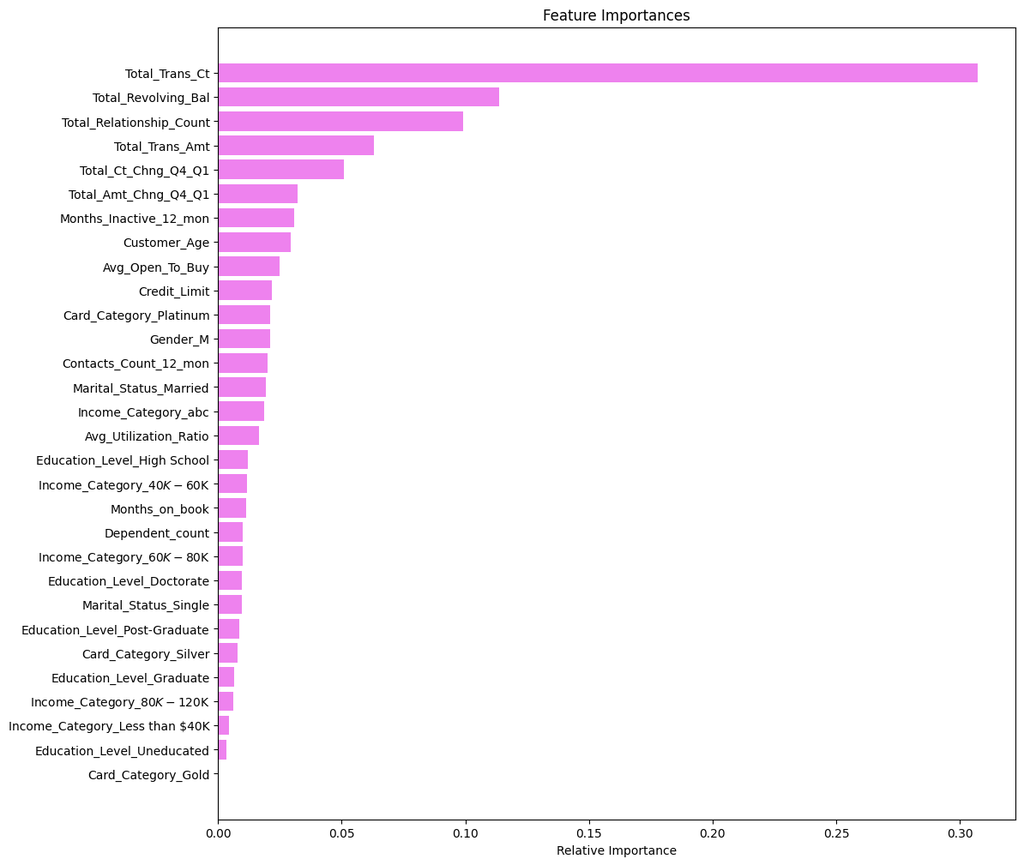

```python
feature_names = X_train.columns
importances = tuned_xgb.feature_importances_  # This retrieves the feature importances from the XGBoost model
indices = np.argsort(importances)

plt.figure(figsize=(12, 12))
plt.title("Feature Importances")
plt.barh(range(len(indices)), importances[indices], color="violet", align="center")
plt.yticks(range(len(indices)), [feature_names[i] for i in indices])
plt.xlabel("Relative Importance")
plt.show()
```

#### XGBoost model on oversampled data (second choice)

```python
from sklearn.metrics import accuracy_score, recall_score, precision_score, f1_score, classification_report
import pandas as pd

# Assuming tuned_xgb_oversampling is your best tuned XGBoost model trained on oversampled data and is already fitted
# Ensure your model, X_test, and y_test are correctly initialized and available

# Predicting the test set results
y_pred_test = tuned_xgb_oversampling.predict(X_test)

# Calculating performance metrics
accuracy = accuracy_score(y_test, y_pred_test)
recall = recall_score(y_test, y_pred_test)
precision = precision_score(y_test, y_pred_test)
f1 = f1_score(y_test, y_pred_test)

# Creating a DataFrame to display the metrics
test_metrics_df = pd.DataFrame({
    'Metric': ['Accuracy', 'Recall', 'Precision', 'F1 Score'],
    'Score': [accuracy, recall, precision, f1]
})

# Printing the performance metrics
print("Performance of the XGBoost model (trained on oversampled training set) on test data:")
print(test_metrics_df)

# Optional: Detailed classification report
report = classification_report(y_test, y_pred_test)
print("\nDetailed Classification Report:")
print(report)
```

```
Performance of the XGBoost model (trained on oversampled training set) on test data:
      Metric  Score
0   Accuracy  0.669
1     Recall  0.996
2  Precision  0.326
3   F1 Score  0.491

Detailed Classification Report:
              precision    recall  f1-score   support

           0       1.00      0.61      0.75      1275
           1       0.33      1.00      0.49       244

    accuracy                           0.67      1519
   macro avg       0.66      0.80      0.62      1519
weighted avg       0.89      0.67      0.71      1519
```

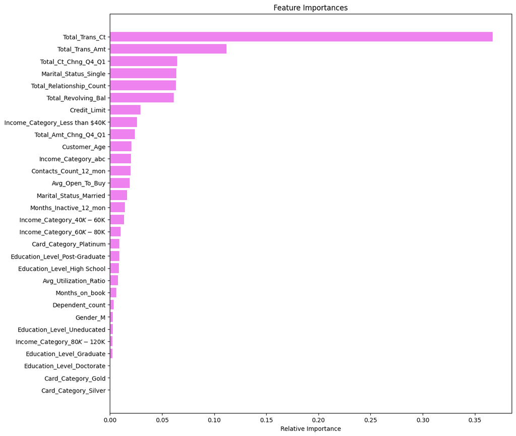

```python
feature_names = X_train.columns
importances = tuned_xgb_oversampling.feature_importances_  # This retrieves the feature importances from the XGBoost model
indices = np.argsort(importances)

plt.figure(figsize=(12, 12))
plt.title("Feature Importances")
plt.barh(range(len(indices)), importances[indices], color="violet", align="center")
plt.yticks(range(len(indices)), [feature_names[i] for i in indices])
plt.xlabel("Relative Importance")
plt.show()
```

#### ADABoost model on original data (Third Choice)

```python
from sklearn.metrics import accuracy_score, recall_score, precision_score, f1_score, classification_report
import pandas as pd

# Assuming a and is already fitted
# Ensure your model, X_test, and y_test are correctly initialized and available

# Predicting the test set results
y_pred_test = tuned_adb.predict(X_test)

# Calculating performance metrics
accuracy = accuracy_score(y_test, y_pred_test)
recall = recall_score(y_test, y_pred_test)
precision = precision_score(y_test, y_pred_test)
f1 = f1_score(y_test, y_pred_test)

# Creating a DataFrame to display the metrics
test_metrics_df = pd.DataFrame({
    'Metric': ['Accuracy', 'Recall', 'Precision', 'F1 Score'],
    'Score': [accuracy, recall, precision, f1]
})

# Printing the performance metrics
print("Performance of the ADABoost model (trained on original training set ) on test data:")
print(test_metrics_df)

# Optional: Detailed classification report
report = classification_report(y_test, y_pred_test)
print("\nDetailed Classification Report:")
print(report)
```

```
Performance of the ADABoost model (trained on original training set ) on test data:
      Metric  Score
0   Accuracy  0.968
1     Recall  0.848
2  Precision  0.945
3   F1 Score  0.894

Detailed Classification Report:
              precision    recall  f1-score   support

           0       0.97      0.99      0.98      1275
           1       0.95      0.85      0.89       244

    accuracy                           0.97      1519
   macro avg       0.96      0.92      0.94      1519
weighted avg       0.97      0.97      0.97      1519
```

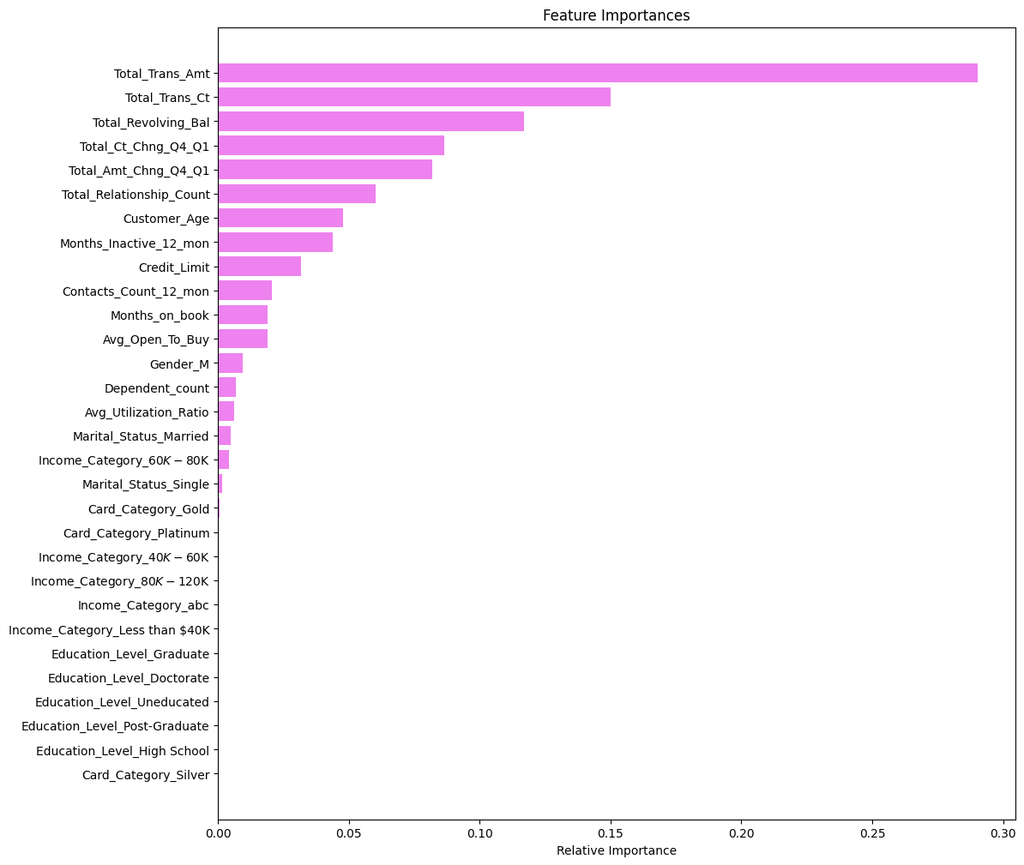

```python
feature_names = X_train.columns
importances = tuned_adb.feature_importances_  # This retrieves the feature importances from the XGBoost model
indices = np.argsort(importances)

plt.figure(figsize=(12, 12))
plt.title("Feature Importances")
plt.barh(range(len(indices)), importances[indices], color="violet", align="center")
plt.yticks(range(len(indices)), [feature_names[i] for i in indices])
plt.xlabel("Relative Importance")
plt.show()
```

**Fianl Selection** **Why Choose AdaBoost Trained with Original Data?** Balanced Performance:

Training Metrics: High accuracy (0.983), excellent recall (0.925), outstanding precision (0.965), and a very high F1 score (0.945). Validation Metrics: Consistently high accuracy (0.982), strong recall (0.901), exceptional precision (0.986), and impressive F1 score (0.942). Generalization Capability:

The AdaBoost model trained on original data shows less overfitting compared to others, evidenced by the minimal drop in performance from training to validation. This suggests that the model generalizes well to new, unseen data. Precision and Recall Balance:

It manages to achieve a high recall without sacrificing precision. This balance is crucial for ensuring that while the primary goal of reducing false negatives is met, the model does not overly compromise on false positives. High precision means the model is also reliable in its positive predictions, which is essential for operational efficiency and customer experience. Operational Implications:

Given its high precision and recall, the model's predictions are likely to be trustworthy, minimizing unnecessary interventions with customers who are not at risk of attrition. This reliability can help maintain customer trust and satisfaction, which are vital for retention strategies. Resource Efficiency:

By minimizing unnecessary interventions (thanks to its high precision), the model helps ensure that resources are allocated efficiently, targeting only those customers truly at risk. This efficiency is not only cost-effective but also potentially increases the effectiveness of intervention strategies. Conclusion: The AdaBoost Trained with Original Data model not only meets the critical requirement of high recall but also ensures high overall accuracy and precision, making it the most robust and reliable choice for practical deployment in a customer attrition context. This model is likely to provide the most balanced approach, helping to prevent customer attrition without excessive costs related to managing false positives

# Business Insights and Conclusions

**Business Insights and Conclusions for Thera Bank Credit Card Services Project Key Findings from Model Analysis:**

**Strategic Recommendations for Thera Bank Credit Card Services:**

**Enhance Customer Engagement:**

- Transactional Bonuses: Implement rewards programs that incentivize frequent transactions or higher spending, thus encouraging continual engagement with the card.
- Engagement Programs: Develop targeted engagement initiatives for customers showing a decline in transaction activity or revolving balance, as these are key indicators of potential churn.

**Product Cross-Selling:**

- Personalized Offers: Utilize insights from the total relationship count to offer personalized product bundles or services, increasing the number of bank touchpoints per customer.
- Loyalty Programs: Enhance loyalty programs to reward customers with multiple product holdings, which could solidify their relationship with the bank. Financial Health Monitoring:
- Credit Management Tools: Provide tools and advisories that help customers manage their credit effectively, especially those with high revolving balances, to prevent financial stress that could lead to account closure.
- Early Warning Systems: Develop predictive models to identify early signs of financial distress based on changes in transaction behavior and revolving balances.

**Customer Retention Strategies:**

- Proactive Retention Campaigns: Implement retention campaigns that proactively address the needs of customers predicted to churn, offering tailored solutions based on their transaction behaviors and product usage.
- Customer Satisfaction Surveys: Regularly engage with customers through satisfaction surveys, especially those who show signs of decreased engagement, to identify and address grievances promptly.

**Risk Management:**

- Adjust Credit Limits: Use insights from revolving balances and credit utilization to adjust credit limits responsibly, ensuring customers have enough credit for their needs without increasing risk excessively.
- Segment-Based Risk Analysis: Analyze transaction and revolving balance data to segment customers by risk level, tailoring credit offers and terms to balance customer needs with bank risk policies.

**Conclusion:**

The models developed and insights gained provide Thera Bank with robust tools to understand and predict customer behavior, particularly around credit card usage and retention. By integrating these insights into operational strategies, Thera Bank can not only reduce customer churn but also enhance customer satisfaction and financial performance. These targeted actions, informed by data-driven insights, will enable Thera Bank to strengthen customer loyalty, optimize service offerings, and maintain a competitive edge in the banking sector.

# Appendix

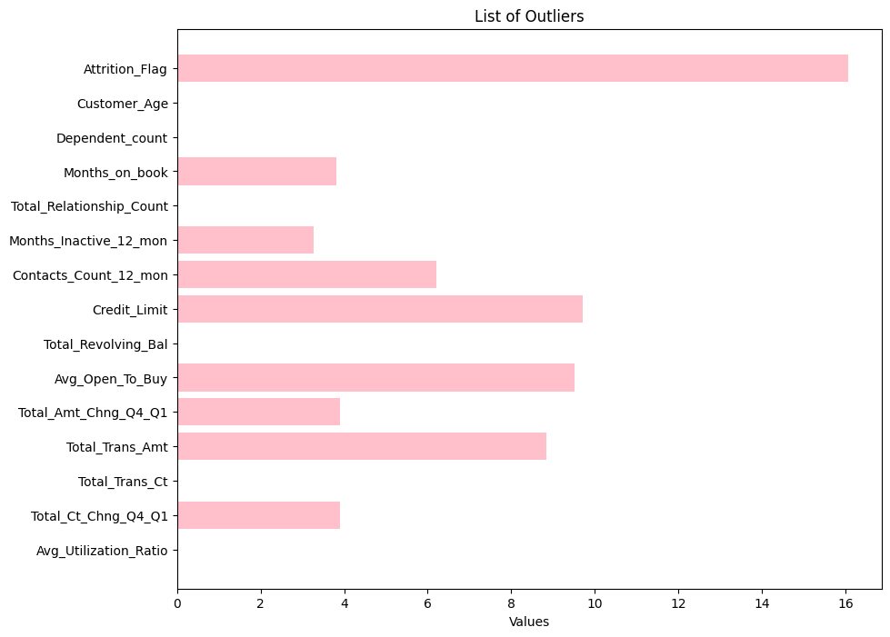

```python
import pandas as pd
import matplotlib.pyplot as plt

# Creating a DataFrame from the given data
data = {
    'Attribute': [
        'Attrition_Flag', 'Customer_Age', 'Dependent_count', 'Months_on_book',
        'Total_Relationship_Count', 'Months_Inactive_12_mon', 'Contacts_Count_12_mon',
        'Credit_Limit', 'Total_Revolving_Bal', 'Avg_Open_To_Buy', 'Total_Amt_Chng_Q4_Q1',
        'Total_Trans_Amt', 'Total_Trans_Ct', 'Total_Ct_Chng_Q4_Q1', 'Avg_Utilization_Ratio'
    ],
    'Value': [
        16.066, 0.020, 0.000, 3.812, 0.000, 3.268, 6.211, 9.717, 0.000, 9.509,
        3.910, 8.848, 0.020, 3.891, 0.000
    ]
}

df = pd.DataFrame(data)

# Creating the bar plot
plt.figure(figsize=(10, 8))
plt.barh(df['Attribute'], df['Value'], color='pink')
plt.xlabel('Values')
plt.title('List of Outliers')
plt.gca().invert_yaxis()  # This will display the highest value at the top
plt.show()
```

```python
# For Google Colab
%matplotlib inline
import matplotlib.pyplot as plt

# Data for the graph
categories = ['Floats', 'Integers', 'Categories']
counts = [5, 10, 6]

# Dataset Overview information
initial_shape = (10127, 21)

# Plotting the graph
fig, ax = plt.subplots()

# Create a bar chart
bars = ax.bar(categories, counts, color=['skyblue', 'salmon', 'lightgreen'])

# Adding text annotations
for bar in bars:
    height = bar.get_height()
    ax.annotate(f'{height}', xy=(bar.get_x() + bar.get_width() / 2, height),
                xytext=(0, 3),  # 3 points vertical offset
                textcoords="offset points",
                ha='center', va='bottom')

# Setting the title and labels
ax.set_title('Dataset Overview')
ax.set_xlabel('Data Types')
ax.set_ylabel('Count')
ax.text(-0.5, 6, f'Initial shape: {initial_shape}', fontsize=12, color='blue')

# Display the plot
plt.show()
```

[output not shown]

-